# Risk Factor Analysis

## Outcome Variable

**Outcome Variable:** pers_wasted624

## Predictor Variables

**Intervention Variable:** ever_co06

**Adjustment Set:**

- sex
- arm
- enstunt
- month
- brthmon
- vagbrth
- single
- W_gagebrth
- W_birthwt
- W_birthlen
- W_mage
- W_mhtcm
- W_meducyrs
- W_feducyrs
- W_parity
- delta_month
- delta_brthmon
- delta_vagbrth
- delta_single
- delta_W_gagebrth
- delta_W_birthwt
- delta_W_birthlen
- delta_W_mage
- delta_W_mhtcm
- delta_W_meducyrs
- delta_W_feducyrs
- delta_W_parity

## Stratifying Variables

The analysis was stratified on these variable(s):

- studyid
- country

## Data Summary

| studyid | country | ever_co06 | pers_wasted624 | n_cell | n |
| --- | --- | --- | --- | --- | --- |
| ki0047075b-MAL-ED | BANGLADESH | 0 | 0 | 215 | 239 |
| ki0047075b-MAL-ED | BANGLADESH | 0 | 1 | 16 | 239 |
| ki0047075b-MAL-ED | BANGLADESH | 1 | 0 | 6 | 239 |
| ki0047075b-MAL-ED | BANGLADESH | 1 | 1 | 2 | 239 |
| ki0047075b-MAL-ED | BRAZIL | 0 | 0 | 200 | 202 |
| ki0047075b-MAL-ED | BRAZIL | 0 | 1 | 2 | 202 |
| ki0047075b-MAL-ED | BRAZIL | 1 | 0 | 0 | 202 |
| ki0047075b-MAL-ED | BRAZIL | 1 | 1 | 0 | 202 |
| ki0047075b-MAL-ED | INDIA | 0 | 0 | 196 | 234 |
| ki0047075b-MAL-ED | INDIA | 0 | 1 | 21 | 234 |
| ki0047075b-MAL-ED | INDIA | 1 | 0 | 10 | 234 |
| ki0047075b-MAL-ED | INDIA | 1 | 1 | 7 | 234 |
| ki0047075b-MAL-ED | NEPAL | 0 | 0 | 227 | 234 |
| ki0047075b-MAL-ED | NEPAL | 0 | 1 | 1 | 234 |
| ki0047075b-MAL-ED | NEPAL | 1 | 0 | 5 | 234 |
| ki0047075b-MAL-ED | NEPAL | 1 | 1 | 1 | 234 |
| ki0047075b-MAL-ED | PERU | 0 | 0 | 261 | 264 |
| ki0047075b-MAL-ED | PERU | 0 | 1 | 2 | 264 |
| ki0047075b-MAL-ED | PERU | 1 | 0 | 1 | 264 |
| ki0047075b-MAL-ED | PERU | 1 | 1 | 0 | 264 |
| ki0047075b-MAL-ED | SOUTH AFRICA | 0 | 0 | 252 | 258 |
| ki0047075b-MAL-ED | SOUTH AFRICA | 0 | 1 | 2 | 258 |
| ki0047075b-MAL-ED | SOUTH AFRICA | 1 | 0 | 4 | 258 |
| ki0047075b-MAL-ED | SOUTH AFRICA | 1 | 1 | 0 | 258 |
| ki0047075b-MAL-ED | TANZANIA, UNITED REPUBLIC OF | 0 | 0 | 240 | 244 |
| ki0047075b-MAL-ED | TANZANIA, UNITED REPUBLIC OF | 0 | 1 | 0 | 244 |
| ki0047075b-MAL-ED | TANZANIA, UNITED REPUBLIC OF | 1 | 0 | 4 | 244 |
| ki0047075b-MAL-ED | TANZANIA, UNITED REPUBLIC OF | 1 | 1 | 0 | 244 |
| ki1000108-CMC-V-BCS-2002 | INDIA | 0 | 0 | 315 | 368 |
| ki1000108-CMC-V-BCS-2002 | INDIA | 0 | 1 | 22 | 368 |

[output cut: 118 more lines]

The following strata were considered:

- studyid: ki0047075b-MAL-ED, country: BANGLADESH
- studyid: ki0047075b-MAL-ED, country: BRAZIL
- studyid: ki0047075b-MAL-ED, country: INDIA
- studyid: ki0047075b-MAL-ED, country: NEPAL
- studyid: ki0047075b-MAL-ED, country: PERU
- studyid: ki0047075b-MAL-ED, country: SOUTH AFRICA
- studyid: ki0047075b-MAL-ED, country: TANZANIA, UNITED REPUBLIC OF
- studyid: ki1000108-CMC-V-BCS-2002, country: INDIA
- studyid: ki1000108-IRC, country: INDIA
- studyid: ki1000109-EE, country: PAKISTAN
- studyid: ki1000109-ResPak, country: PAKISTAN
- studyid: ki1000304-VITAMIN-A, country: INDIA
- studyid: ki1000304b-SAS-CompFeed, country: INDIA
- studyid: ki1000304b-SAS-FoodSuppl, country: INDIA
- studyid: ki1017093-NIH-Birth, country: BANGLADESH
- studyid: ki1017093b-PROVIDE, country: BANGLADESH
- studyid: ki1017093c-NIH-Crypto, country: BANGLADESH
- studyid: ki1066203-TanzaniaChild2, country: TANZANIA, UNITED REPUBLIC OF
- studyid: ki1101329-Keneba, country: GAMBIA
- studyid: ki1112895-Burkina Faso Zn, country: BURKINA FASO
- studyid: ki1112895-Guatemala BSC, country: GUATEMALA
- studyid: ki1113344-GMS-Nepal, country: NEPAL
- studyid: ki1114097-CMIN, country: BANGLADESH
- studyid: ki1114097-CMIN, country: BRAZIL
- studyid: ki1114097-CMIN, country: GUINEA-BISSAU
- studyid: ki1114097-CMIN, country: PERU
- studyid: ki1114097-CONTENT, country: PERU
- studyid: ki1119695-PROBIT, country: BELARUS
- studyid: ki1126311-ZVITAMBO, country: ZIMBABWE
- studyid: ki1135781-COHORTS, country: GUATEMALA
- studyid: ki1135781-COHORTS, country: INDIA
- studyid: ki1135781-COHORTS, country: PHILIPPINES
- studyid: ki1148112-iLiNS-DOSE, country: MALAWI
- studyid: ki1148112-iLiNS-DYAD-M, country: MALAWI
- studyid: ki1148112-LCNI-5, country: MALAWI
- studyid: kiGH5241-JiVitA-3, country: BANGLADESH
- studyid: kiGH5241-JiVitA-4, country: BANGLADESH

### Dropped Strata

Some strata were dropped due to rare outcomes:

- studyid: ki0047075b-MAL-ED, country: BANGLADESH
- studyid: ki0047075b-MAL-ED, country: BRAZIL
- studyid: ki0047075b-MAL-ED, country: NEPAL
- studyid: ki0047075b-MAL-ED, country: PERU
- studyid: ki0047075b-MAL-ED, country: SOUTH AFRICA
- studyid: ki0047075b-MAL-ED, country: TANZANIA, UNITED REPUBLIC OF
- studyid: ki1000109-ResPak, country: PAKISTAN
- studyid: ki1017093c-NIH-Crypto, country: BANGLADESH
- studyid: ki1112895-Burkina Faso Zn, country: BURKINA FASO
- studyid: ki1112895-Guatemala BSC, country: GUATEMALA
- studyid: ki1114097-CMIN, country: BRAZIL
- studyid: ki1114097-CMIN, country: GUINEA-BISSAU
- studyid: ki1114097-CMIN, country: PERU
- studyid: ki1114097-CONTENT, country: PERU
- studyid: ki1119695-PROBIT, country: BELARUS
- studyid: ki1135781-COHORTS, country: GUATEMALA
- studyid: ki1148112-iLiNS-DOSE, country: MALAWI
- studyid: ki1148112-iLiNS-DYAD-M, country: MALAWI
- studyid: ki1148112-LCNI-5, country: MALAWI

## Methods Detail

We’re interested in the causal parameters $E[Y_a]$ for all values of $a \in \mathcal{A}$. These parameters represent the mean outcome if, possibly contrary to fact, we intervened to set all units to have $A=a$. Under the randomization and positivity assumptions, these are identified by the statistical parameters $\psi_a=E_W[E_{Y|A,W}(Y|A=a,W)]$. In addition, we’re interested in the mean of $Y$, $E[Y]$ under no intervention (the observed mean). We will estimate these parameters by using SuperLearner to fit the relevant likelihood factors – $E_{Y|A,W}(Y|A=a,W)$ and $p(A=a|W)$, and then updating our likelihood fit using a joint TMLE.

For unadjusted analyses ($W=\{\}$), initial likelihoods were estimated using Lrnr_glm to estimate the simple $E(Y|A)$ and Lrnr_mean to estimate $p(A)$. For adjusted analyses, a small library containing Lrnr_glmnet, Lrnr_xgboost, and Lrnr_mean was used.

Having estimated these parameters, we will then use the delta method to estimate relative risks and attributable risks relative to a prespecified baseline level of $A$.

# Results Detail

## Results Plots

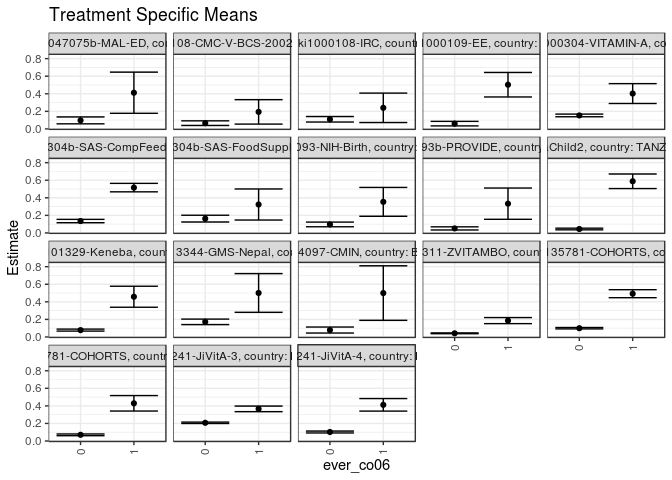

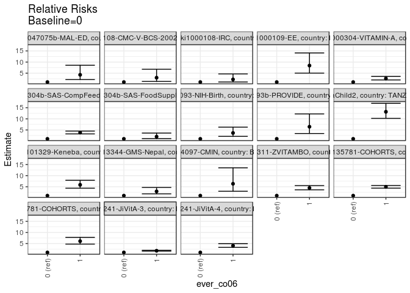

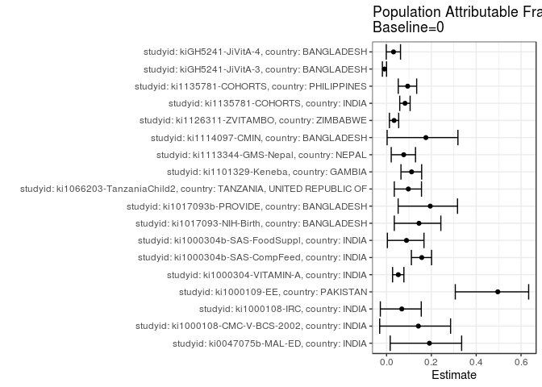

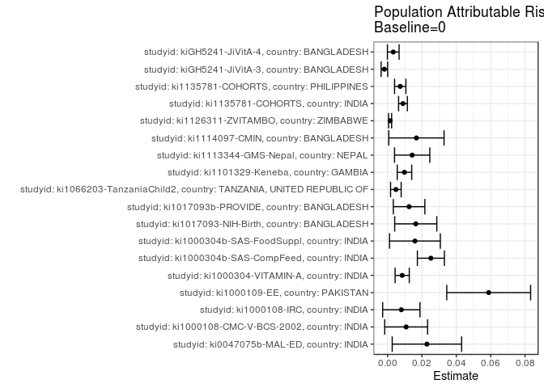

## Results Table

### Parameter: TSM

| studyid | country | intervention_level | baseline_level | estimate | ci_lower | ci_upper |
| --- | --- | --- | --- | --- | --- | --- |
| ki0047075b-MAL-ED | INDIA | 0 | NA | 0.0967742 | 0.0573533 | 0.1361951 |
| ki0047075b-MAL-ED | INDIA | 1 | NA | 0.4117647 | 0.1773128 | 0.6462166 |
| ki1000108-CMC-V-BCS-2002 | INDIA | 0 | NA | 0.0652819 | 0.0388724 | 0.0916914 |
| ki1000108-CMC-V-BCS-2002 | INDIA | 1 | NA | 0.1935484 | 0.0542834 | 0.3328134 |
| ki1000108-IRC | INDIA | 0 | NA | 0.1093750 | 0.0781199 | 0.1406301 |
| ki1000108-IRC | INDIA | 1 | NA | 0.2400000 | 0.0723815 | 0.4076185 |
| ki1000109-EE | PAKISTAN | 0 | NA | 0.0597381 | 0.0337541 | 0.0857222 |
| ki1000109-EE | PAKISTAN | 1 | NA | 0.5031581 | 0.3637030 | 0.6426131 |
| ki1000304-VITAMIN-A | INDIA | 0 | NA | 0.1532457 | 0.1382829 | 0.1682084 |
| ki1000304-VITAMIN-A | INDIA | 1 | NA | 0.4023593 | 0.2892114 | 0.5155072 |
| ki1000304b-SAS-CompFeed | INDIA | 0 | NA | 0.1352753 | 0.1162253 | 0.1543252 |
| ki1000304b-SAS-CompFeed | INDIA | 1 | NA | 0.5161358 | 0.4680081 | 0.5642635 |
| ki1000304b-SAS-FoodSuppl | INDIA | 0 | NA | 0.1628453 | 0.1244248 | 0.2012659 |
| ki1000304b-SAS-FoodSuppl | INDIA | 1 | NA | 0.3236766 | 0.1468124 | 0.5005408 |
| ki1017093-NIH-Birth | BANGLADESH | 0 | NA | 0.0968915 | 0.0702516 | 0.1235314 |
| ki1017093-NIH-Birth | BANGLADESH | 1 | NA | 0.3539239 | 0.1898162 | 0.5180316 |
| ki1017093b-PROVIDE | BANGLADESH | 0 | NA | 0.0516351 | 0.0336266 | 0.0696436 |
| ki1017093b-PROVIDE | BANGLADESH | 1 | NA | 0.3333333 | 0.1553754 | 0.5112913 |
| ki1066203-TanzaniaChild2 | TANZANIA, UNITED REPUBLIC OF | 0 | NA | 0.0446429 | 0.0352105 | 0.0540752 |
| ki1066203-TanzaniaChild2 | TANZANIA, UNITED REPUBLIC OF | 1 | NA | 0.5882353 | 0.5053994 | 0.6710711 |
| ki1101329-Keneba | GAMBIA | 0 | NA | 0.0780946 | 0.0666490 | 0.0895402 |
| ki1101329-Keneba | GAMBIA | 1 | NA | 0.4581740 | 0.3385298 | 0.5778182 |
| ki1113344-GMS-Nepal | NEPAL | 0 | NA | 0.1723362 | 0.1409493 | 0.2037232 |
| ki1113344-GMS-Nepal | NEPAL | 1 | NA | 0.5011059 | 0.2806097 | 0.7216021 |
| ki1114097-CMIN | BANGLADESH | 0 | NA | 0.0788382 | 0.0447469 | 0.1129294 |
| ki1114097-CMIN | BANGLADESH | 1 | NA | 0.5000000 | 0.1894833 | 0.8105167 |
| ki1126311-ZVITAMBO | ZIMBABWE | 0 | NA | 0.0416551 | 0.0373240 | 0.0459862 |
| ki1126311-ZVITAMBO | ZIMBABWE | 1 | NA | 0.1862713 | 0.1517751 | 0.2207675 |
| ki1135781-COHORTS | INDIA | 0 | NA | 0.0996726 | 0.0917437 | 0.1076016 |
| ki1135781-COHORTS | INDIA | 1 | NA | 0.4926587 | 0.4470528 | 0.5382647 |
| ki1135781-COHORTS | PHILIPPINES | 0 | NA | 0.0706576 | 0.0608980 | 0.0804172 |
| ki1135781-COHORTS | PHILIPPINES | 1 | NA | 0.4292806 | 0.3412181 | 0.5173431 |
| kiGH5241-JiVitA-3 | BANGLADESH | 0 | NA | 0.2074039 | 0.1997256 | 0.2150822 |
| kiGH5241-JiVitA-3 | BANGLADESH | 1 | NA | 0.3660518 | 0.3342270 | 0.3978766 |
| kiGH5241-JiVitA-4 | BANGLADESH | 0 | NA | 0.1024705 | 0.0917537 | 0.1131872 |
| kiGH5241-JiVitA-4 | BANGLADESH | 1 | NA | 0.4119289 | 0.3405214 | 0.4833365 |

### Parameter: E(Y)

| studyid | country | intervention_level | baseline_level | estimate | ci_lower | ci_upper |
| --- | --- | --- | --- | --- | --- | --- |
| ki0047075b-MAL-ED | INDIA | NA | NA | 0.1196581 | 0.0779840 | 0.1613323 |
| ki1000108-CMC-V-BCS-2002 | INDIA | NA | NA | 0.0760870 | 0.0489610 | 0.1032130 |
| ki1000108-IRC | INDIA | NA | NA | 0.1173594 | 0.0861296 | 0.1485892 |
| ki1000109-EE | PAKISTAN | NA | NA | 0.1185984 | 0.0856546 | 0.1515422 |
| ki1000304-VITAMIN-A | INDIA | NA | NA | 0.1617391 | 0.1466878 | 0.1767905 |
| ki1000304b-SAS-CompFeed | INDIA | NA | NA | 0.1604755 | 0.1397079 | 0.1812430 |
| ki1000304b-SAS-FoodSuppl | INDIA | NA | NA | 0.1787565 | 0.1404842 | 0.2170288 |
| ki1017093-NIH-Birth | BANGLADESH | NA | NA | 0.1132813 | 0.0858017 | 0.1407608 |
| ki1017093b-PROVIDE | BANGLADESH | NA | NA | 0.0641447 | 0.0446535 | 0.0836359 |
| ki1066203-TanzaniaChild2 | TANZANIA, UNITED REPUBLIC OF | NA | NA | 0.0494534 | 0.0397554 | 0.0591514 |
| ki1101329-Keneba | GAMBIA | NA | NA | 0.0879121 | 0.0760335 | 0.0997906 |
| ki1113344-GMS-Nepal | NEPAL | NA | NA | 0.1866438 | 0.1550166 | 0.2182711 |
| ki1114097-CMIN | BANGLADESH | NA | NA | 0.0956175 | 0.0591654 | 0.1320697 |
| ki1126311-ZVITAMBO | ZIMBABWE | NA | NA | 0.0431105 | 0.0387958 | 0.0474253 |
| ki1135781-COHORTS | INDIA | NA | NA | 0.1086181 | 0.1006662 | 0.1165699 |
| ki1135781-COHORTS | PHILIPPINES | NA | NA | 0.0780116 | 0.0679971 | 0.0880261 |
| kiGH5241-JiVitA-3 | BANGLADESH | NA | NA | 0.2055161 | 0.1979472 | 0.2130849 |
| kiGH5241-JiVitA-4 | BANGLADESH | NA | NA | 0.1057558 | 0.0949876 | 0.1165240 |

### Parameter: RR

| studyid | country | intervention_level | baseline_level | estimate | ci_lower | ci_upper |
| --- | --- | --- | --- | --- | --- | --- |
| ki0047075b-MAL-ED | INDIA | 0 | 0 | 1.000000 | 1.000000 | 1.000000 |
| ki0047075b-MAL-ED | INDIA | 1 | 0 | 4.254902 | 2.112725 | 8.569117 |
| ki1000108-CMC-V-BCS-2002 | INDIA | 0 | 0 | 1.000000 | 1.000000 | 1.000000 |
| ki1000108-CMC-V-BCS-2002 | INDIA | 1 | 0 | 2.964809 | 1.298682 | 6.768476 |
| ki1000108-IRC | INDIA | 0 | 0 | 1.000000 | 1.000000 | 1.000000 |
| ki1000108-IRC | INDIA | 1 | 0 | 2.194286 | 1.031740 | 4.666768 |
| ki1000109-EE | PAKISTAN | 0 | 0 | 1.000000 | 1.000000 | 1.000000 |
| ki1000109-EE | PAKISTAN | 1 | 0 | 8.422729 | 5.031737 | 14.098982 |
| ki1000304-VITAMIN-A | INDIA | 0 | 0 | 1.000000 | 1.000000 | 1.000000 |
| ki1000304-VITAMIN-A | INDIA | 1 | 0 | 2.625584 | 1.949869 | 3.535462 |
| ki1000304b-SAS-CompFeed | INDIA | 0 | 0 | 1.000000 | 1.000000 | 1.000000 |
| ki1000304b-SAS-CompFeed | INDIA | 1 | 0 | 3.815449 | 3.230577 | 4.506208 |
| ki1000304b-SAS-FoodSuppl | INDIA | 0 | 0 | 1.000000 | 1.000000 | 1.000000 |
| ki1000304b-SAS-FoodSuppl | INDIA | 1 | 0 | 1.987632 | 1.096440 | 3.603191 |
| ki1017093-NIH-Birth | BANGLADESH | 0 | 0 | 1.000000 | 1.000000 | 1.000000 |
| ki1017093-NIH-Birth | BANGLADESH | 1 | 0 | 3.652785 | 2.129590 | 6.265451 |
| ki1017093b-PROVIDE | BANGLADESH | 0 | 0 | 1.000000 | 1.000000 | 1.000000 |
| ki1017093b-PROVIDE | BANGLADESH | 1 | 0 | 6.455556 | 3.411812 | 12.214682 |
| ki1066203-TanzaniaChild2 | TANZANIA, UNITED REPUBLIC OF | 0 | 0 | 1.000000 | 1.000000 | 1.000000 |
| ki1066203-TanzaniaChild2 | TANZANIA, UNITED REPUBLIC OF | 1 | 0 | 13.176470 | 10.221764 | 16.985265 |
| ki1101329-Keneba | GAMBIA | 0 | 0 | 1.000000 | 1.000000 | 1.000000 |
| ki1101329-Keneba | GAMBIA | 1 | 0 | 5.866910 | 4.348911 | 7.914772 |
| ki1113344-GMS-Nepal | NEPAL | 0 | 0 | 1.000000 | 1.000000 | 1.000000 |
| ki1113344-GMS-Nepal | NEPAL | 1 | 0 | 2.907723 | 1.806159 | 4.681123 |
| ki1114097-CMIN | BANGLADESH | 0 | 0 | 1.000000 | 1.000000 | 1.000000 |
| ki1114097-CMIN | BANGLADESH | 1 | 0 | 6.342105 | 2.975646 | 13.517164 |
| ki1126311-ZVITAMBO | ZIMBABWE | 0 | 0 | 1.000000 | 1.000000 | 1.000000 |
| ki1126311-ZVITAMBO | ZIMBABWE | 1 | 0 | 4.471753 | 3.616032 | 5.529978 |
| ki1135781-COHORTS | INDIA | 0 | 0 | 1.000000 | 1.000000 | 1.000000 |
| ki1135781-COHORTS | INDIA | 1 | 0 | 4.942769 | 4.376855 | 5.581853 |
| ki1135781-COHORTS | PHILIPPINES | 0 | 0 | 1.000000 | 1.000000 | 1.000000 |
| ki1135781-COHORTS | PHILIPPINES | 1 | 0 | 6.075505 | 4.745307 | 7.778582 |
| kiGH5241-JiVitA-3 | BANGLADESH | 0 | 0 | 1.000000 | 1.000000 | 1.000000 |
| kiGH5241-JiVitA-3 | BANGLADESH | 1 | 0 | 1.764922 | 1.607255 | 1.938056 |
| kiGH5241-JiVitA-4 | BANGLADESH | 0 | 0 | 1.000000 | 1.000000 | 1.000000 |
| kiGH5241-JiVitA-4 | BANGLADESH | 1 | 0 | 4.019977 | 3.284881 | 4.919574 |

### Parameter: PAR

| studyid | country | intervention_level | baseline_level | estimate | ci_lower | ci_upper |
| --- | --- | --- | --- | --- | --- | --- |
| ki0047075b-MAL-ED | INDIA | 0 | NA | 0.0228839 | 0.0026719 | 0.0430960 |
| ki1000108-CMC-V-BCS-2002 | INDIA | 0 | NA | 0.0108051 | -0.0016795 | 0.0232896 |
| ki1000108-IRC | INDIA | 0 | NA | 0.0079844 | -0.0028711 | 0.0188399 |
| ki1000109-EE | PAKISTAN | 0 | NA | 0.0588603 | 0.0344408 | 0.0832798 |
| ki1000304-VITAMIN-A | INDIA | 0 | NA | 0.0084935 | 0.0043651 | 0.0126219 |
| ki1000304b-SAS-CompFeed | INDIA | 0 | NA | 0.0252002 | 0.0173370 | 0.0330635 |
| ki1000304b-SAS-FoodSuppl | INDIA | 0 | NA | 0.0159111 | 0.0011080 | 0.0307143 |
| ki1017093-NIH-Birth | BANGLADESH | 0 | NA | 0.0163897 | 0.0041301 | 0.0286494 |
| ki1017093b-PROVIDE | BANGLADESH | 0 | NA | 0.0125096 | 0.0033225 | 0.0216968 |
| ki1066203-TanzaniaChild2 | TANZANIA, UNITED REPUBLIC OF | 0 | NA | 0.0048106 | 0.0017235 | 0.0078976 |
| ki1101329-Keneba | GAMBIA | 0 | NA | 0.0098175 | 0.0055983 | 0.0140367 |
| ki1113344-GMS-Nepal | NEPAL | 0 | NA | 0.0143076 | 0.0040416 | 0.0245737 |
| ki1114097-CMIN | BANGLADESH | 0 | NA | 0.0167794 | 0.0006811 | 0.0328776 |
| ki1126311-ZVITAMBO | ZIMBABWE | 0 | NA | 0.0014554 | 0.0005631 | 0.0023478 |
| ki1135781-COHORTS | INDIA | 0 | NA | 0.0089454 | 0.0064057 | 0.0114851 |
| ki1135781-COHORTS | PHILIPPINES | 0 | NA | 0.0073540 | 0.0040538 | 0.0106542 |
| kiGH5241-JiVitA-3 | BANGLADESH | 0 | NA | -0.0018879 | -0.0037911 | 0.0000154 |
| kiGH5241-JiVitA-4 | BANGLADESH | 0 | NA | 0.0032854 | -0.0001183 | 0.0066890 |

### Parameter: PAF

| studyid | country | intervention_level | baseline_level | estimate | ci_lower | ci_upper |
| --- | --- | --- | --- | --- | --- | --- |
| ki0047075b-MAL-ED | INDIA | 0 | NA | 0.1912442 | 0.0163422 | 0.3350473 |
| ki1000108-CMC-V-BCS-2002 | INDIA | 0 | NA | 0.1420093 | -0.0305521 | 0.2856761 |
| ki1000108-IRC | INDIA | 0 | NA | 0.0680339 | -0.0277289 | 0.1548735 |
| ki1000109-EE | PAKISTAN | 0 | NA | 0.4962990 | 0.3067305 | 0.6340316 |
| ki1000304-VITAMIN-A | INDIA | 0 | NA | 0.0525134 | 0.0269587 | 0.0773970 |
| ki1000304b-SAS-CompFeed | INDIA | 0 | NA | 0.1570347 | 0.1108719 | 0.2008008 |
| ki1000304b-SAS-FoodSuppl | INDIA | 0 | NA | 0.0890101 | 0.0037533 | 0.1669709 |
| ki1017093-NIH-Birth | BANGLADESH | 0 | NA | 0.1446818 | 0.0345237 | 0.2422712 |
| ki1017093b-PROVIDE | BANGLADESH | 0 | NA | 0.1950218 | 0.0517373 | 0.3166558 |
| ki1066203-TanzaniaChild2 | TANZANIA, UNITED REPUBLIC OF | 0 | NA | 0.0972744 | 0.0345319 | 0.1559395 |
| ki1101329-Keneba | GAMBIA | 0 | NA | 0.1116740 | 0.0643258 | 0.1566262 |
| ki1113344-GMS-Nepal | NEPAL | 0 | NA | 0.0766574 | 0.0209209 | 0.1292209 |
| ki1114097-CMIN | BANGLADESH | 0 | NA | 0.1754841 | 0.0025370 | 0.3184444 |
| ki1126311-ZVITAMBO | ZIMBABWE | 0 | NA | 0.0337607 | 0.0128502 | 0.0542283 |
| ki1135781-COHORTS | INDIA | 0 | NA | 0.0823567 | 0.0589216 | 0.1052082 |
| ki1135781-COHORTS | PHILIPPINES | 0 | NA | 0.0942682 | 0.0522202 | 0.1344507 |
| kiGH5241-JiVitA-3 | BANGLADESH | 0 | NA | -0.0091859 | -0.0185187 | 0.0000614 |
| kiGH5241-JiVitA-4 | BANGLADESH | 0 | NA | 0.0310655 | -0.0012514 | 0.0623392 |